# Week 7 and 8 Homework

Author

Anna Hiltner Nouzeilles

# Comparison #1: Age and TV Hours

Here we can see the difference in mean hours of TV watched between respondents above and below the age of 50:

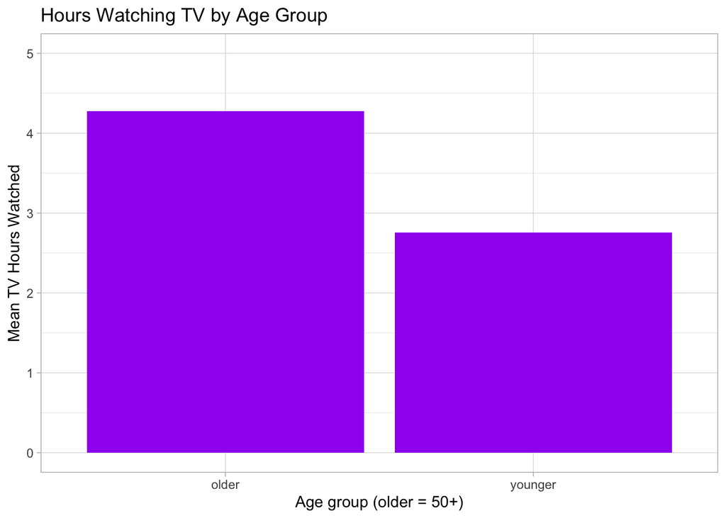

And in a density plot:

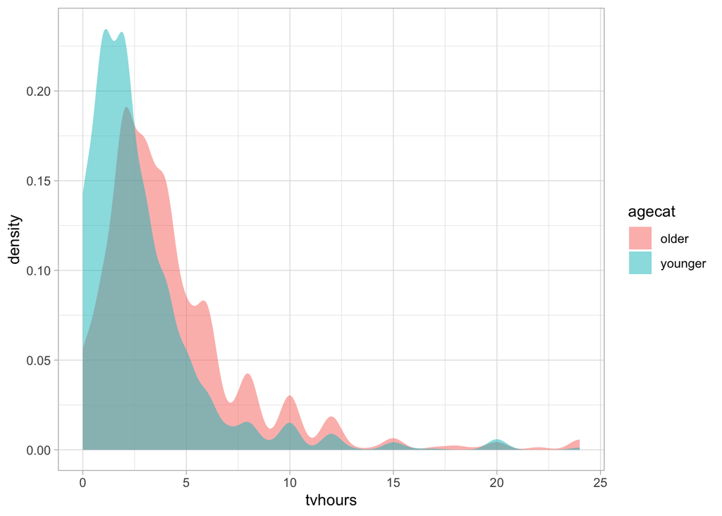

## Hypothesis Test: Age and TV Hours

We can then conduct a hypothesis test using this formula and alpha level 0.05:

$$H_0: \mu_{\tiny{older}} - \mu_{\tiny{younger}} = 0 \\ H_1: \mu_{\tiny{older}} - \mu_{\tiny{younger}} \neq 0$$

The z-statistic for tvhours and age is 11.2 and the p-value is almost 0. Since the p-value of 0 is lower than alpha level 0.05, we can reject the null hypothesis. I can also use the 95% confidence interval of [1.25, 1.79] to reject the null hypothesis.

## Cohen’s D and Probability of Superiority

```
Cohen's d |       95% CI
------------------------
0.45      | [0.38, 0.53]

- Estimated using pooled SD.
```

```
Pr(superiority) |       95% CI
------------------------------
0.63            | [0.60, 0.65]
```

## Power Analysis

To know how small of an effect size I could detect 80% of the time using these group sizes and an alpha level of 0.05, I conducted a power analysis and find an effect size as small as 0.1107 .

### Imaginary Experiment

To estimate the sample size I would need for an imaginary experiment, I’ve picked an effect size of .2, an alpha level of 0.05, and a power level of .9. The imaginary experiment tests whether a new voter registration system increases voter turnout. Since small changes in voter turnout can be politically meaningful, I use a higher power and smaller effect size. With these values, I would need a sample size of 525.37 .

# Comparison #2: College Education and Weight

Here we compare weight between individuals with and without a bachelors degree. As you can see, there does not seem to be a large difference:

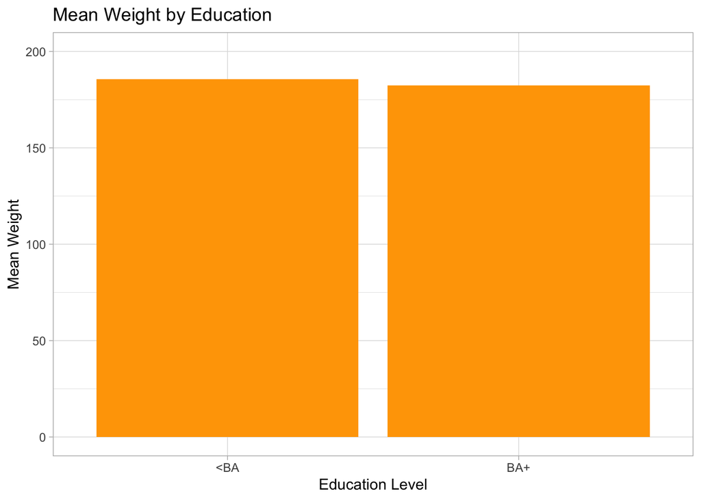

The density plot:

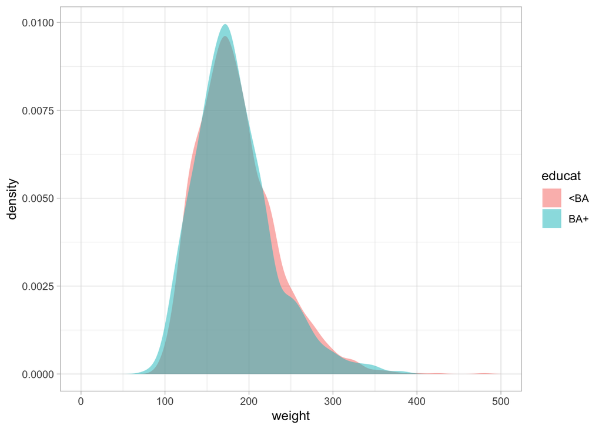

## Hypothesis Test for College Education and Weight

The z-statistic for Education and Weight is -1.33 and the p-value is .18. Since the p-value of 0.18 is higher than alpha level 0.05, we fail to reject the null hypothesis. I can also use the 95% confidence interval of [-8.2, 1.55] to fail to reject the null hypothesis.

## Cohen’s D and Probability of Superiority

```
Pr(superiority) |       95% CI
------------------------------
0.52            | [0.49, 0.55]
```

```
Cohen's d |        95% CI
-------------------------
0.07      | [-0.04, 0.17]

- Estimated using pooled SD.
```

Cohen’s d for eduweight is 0.07. The probability of superiority for eduweight is 0.52 if we use a normal approximation. The probability of superiority is 0.52 if we calculate it directly from the data.

# Comparison #3: Marijuana Legalization and Sex

Here we can see support for marijuana legalization by sex:

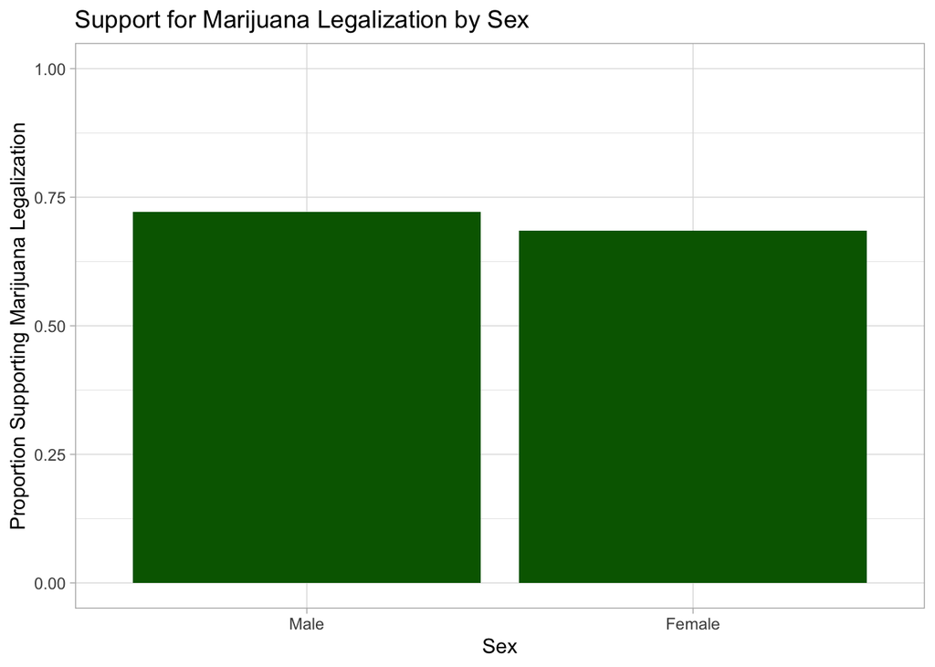

## Hypothesis Test: Marijuana Legalization and Sex

The z-statistic for comparing marijuana legalization and sex is 1.32 and the p-value is .19. Since the p-value is higher than alpha level 0.05, we fail to reject the null hypothesis. I can also use the 95% confidence interval of [-0.017, 0.09] to fail to reject the null hypothesis.

# Comparison #4: Death Penalty and Sex

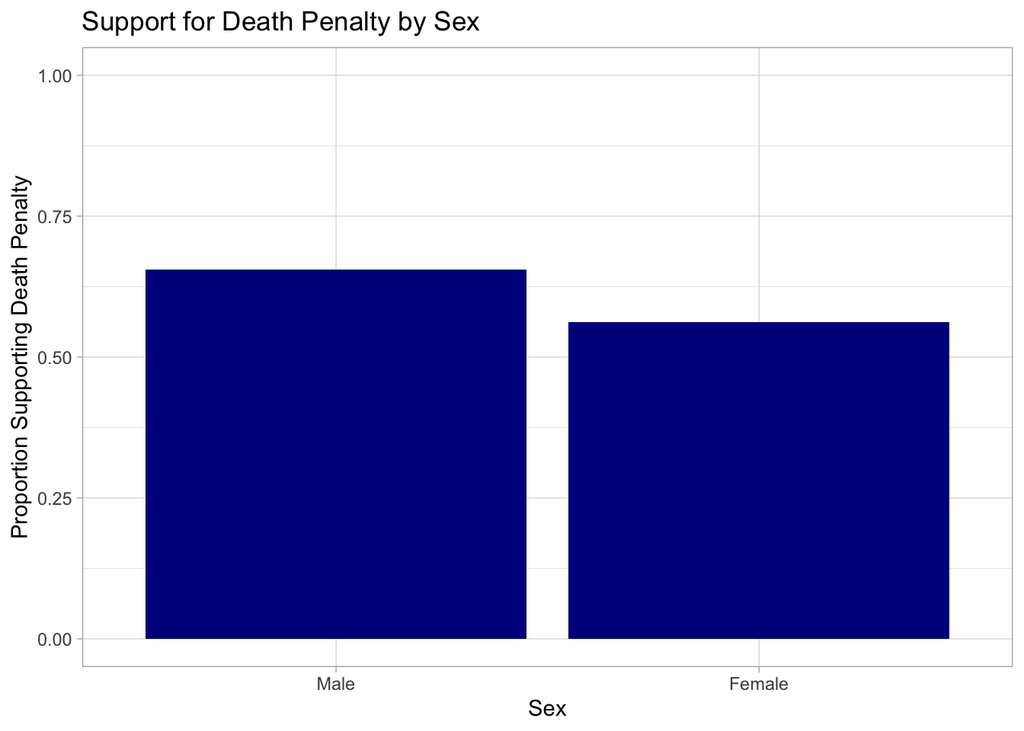

## Hypothesis Test: Death Penalty and Sex

$$Z=\dfrac{(\hat{p}_1-\hat{p}_2)}{\sqrt{\hat{p}(1-\hat{p})\left(\dfrac{1}{n_1}+\dfrac{1}{n_2}\right)}}$$

The z-statistic for comparing the Death Penalty and Sex is 5.921 and the p-value is almost zero. Since the p-value is lower than alpha level 0.05, we can reject the null hypothesis. I can also use the 95% confidence interval of [0.06, 0.123] to reject the null hypothesis.